# Sauerkraut study - Model-based alpha diversity analysis

```r
library(sauerkrautTaxonomyBuddy)
library(SummarizedExperiment) # microbiome analysis
library(mia)                  # microbiome analysis
library(mgcv)                 # mixed model estimation
library(mgcViz)               # mgcv-based visualizations
library(APCtools)             # mgcv-based tables and visualizations

library(dplyr)      # data handling
library(tidyr)      # data transformation
library(ggplot2)    # data visualization
library(patchwork)  # grid of ggplots
library(kableExtra) # print tables

# set ggplot2 theme
theme_set(
  theme_minimal() +
    theme(plot.title       = element_text(hjust = 0.5),
          plot.subtitle    = element_text(hjust = 0.5),
          panel.grid.minor = element_blank(),
          plot.background  = element_rect(fill = "white", color = "white"))
)
```

# Methodology

For each blood parameter, the below model is estimated in three variants, as described in the paper:

- Gaussian regression model
- Gaussian regression model with log transformation
- Gamma regression model
- sidenote: additionally, Gaussian with square root transformation was evaluated, but due to only small benefits regarding the models’ goodness of fit, and the unintuitive interpretation we’d get from such a square root transformation, it was dropped

Each of the above variants were estimated and the final model was chosen as the model with the highest share of explained deviance per blood parameter.

For each parameter of interest, a separate linear mixed regression model is estimated.

##### General notes

- follow-up measurements were excluded before model estimation
- internal note: nonlinear effects of age and BMI were evaluated for a lot of models, but did not lead to (structural) improvements of any of the models’ predictive power. In most models, it didn’t change the explained deviance share at all.
- internal note: age-specific intervention effects were only evaluated for two age groups. Looking at a third group, e.g. at ‘below 30’, suffers of a quite limited sample size

# Data preparation

```r
define_dataPaths()
```

```r
tse <- readAndPrepare_mainTaxonomicData(path_groupInfoRdata               = path_groupInfoRdata,
                                        path_participantRdata             = path_participantRdata,
                                        path_samplesIDxlsx                = path_samplesIDxlsx,
                                        path_dietInfoCsv                  = path_dietInfoCsv,
                                        path_nutrientInfoCsv              = path_nutrientInfoCsv,
                                        path_bloodMetabolomeXlsx          = path_bloodMetabolomeXlsx,
                                        path_stoolMetabolomeXlsx          = path_stoolMetabolomeXlsx,
                                        path_T4questXlsx                  = path_T4questXlsx,
                                        path_stoolInfoXlsx                = path_stoolInfoXlsx,
                                        path_bodyMeasuresXlsx             = path_bodyMeasuresXlsx,
                                        path_absTaxonomyData              = path_absTaxonomyData,
                                        path_relTaxonomyData              = path_relTaxonomyData,
                                        path_sampleLookupXlsx             = path_sampleLookupXlsx,
                                        path_krautLookupXlsx              = path_krautLookupXlsx,
                                        path_bloodMarkerBostonRdata       = path_bloodMarkerBostonRdata,
                                        path_bloodMarkerZentrallaborRdata = path_bloodMarkerZentrallaborRdata,
                                        path_bloodMarkerBostonXlsx        = path_bloodMarkerBostonXlsx,
                                        path_bloodMarkerZentrallaborXlsx  = path_bloodMarkerZentrallaborXlsx,
                                        aggregation_level                 = "species",
                                        exclude_sickParticipants          = "taxonomy paper")

dat <- tse %>%
  colData() %>%
  as.data.frame()
```

```r
# remove follow-up measurements
dat_model <- dat %>%
  filter(intervention != "FollowUp") %>%
  mutate(timepoint    = droplevels(timepoint),
         period       = droplevels(period),
         intervention = droplevels(intervention))

# construct the intervention variable and the carry-over variable
dat_model <- dat_model %>%
  mutate(intervention = case_when(treatment == "Baseline" ~ "Baseline",
                                  TRUE                    ~ intervention),
         carry_over   = case_when(timepoint %in% c("T1", "T2") ~ "not possible (T1, T2)",
                                  group == "Fresh first"       ~ "from fresh intervention",
                                  group == "Pasteurized first" ~ "from pasteurized intervention"),
         carry_over   = factor(carry_over, levels = c("not possible (T1, T2)", "from fresh intervention", "from pasteurized intervention")),
         phase        = case_when(timepoint %in% c("T3","T4") ~ "phase 2",
                                  TRUE                        ~ "phase 1"),
         phase        = factor(phase))

# save the average T1/T3 baseline Shannon diversity as individual variable
dat_baselineDiv <- dat_model %>%
  filter(timepoint %in% c("T1", "T3")) %>%
  group_by(participant_id) %>%
  summarize(baseline_div = mean(diversity_shannon, na.rm = TRUE))
dat_model <- dat_model %>%
  dplyr::left_join(dat_baselineDiv, by = "participant_id")

# categorize the variables for testing category-specific intervention effects
median_baselineDiv <- median(dat_model$baseline_div)
dat_model <- dat_model %>%
  mutate(age_centered50 = age - 50,
         bmi_centered25 = bmi_t0 - 25,
         age_cat = case_when(age < 50 ~ paste0(min(age), "-49"),
                             TRUE     ~ paste0("50-", max(age))),
         age_cat = factor(age_cat),
         bmi_cat = case_when(bmi_t0 < 25 ~ paste0("[", floor(min(bmi_t0)), ", 25)"),
                             TRUE        ~ paste0("[25, ", ceiling(max(bmi_t0)), "]")),
         bmi_cat = factor(bmi_cat),
         dailyFiber_cat  = case_when(dailyConsumption_fiber >= 30 ~ ">= 30g",
                                     TRUE                         ~ "< 30g"),
         dailyFiber_cat  = factor(dailyFiber_cat),
         baselineDiv_cat = case_when(baseline_div < median_baselineDiv ~ "[2.8, 3.85)",
                                     TRUE                              ~ "[3.85, 4.4)"),
         baselineDiv_cat = factor(baselineDiv_cat))
```

```r
markers <- c("Diversity (Shannon)"          = "diversity_shannon",
             "Diversity (inv. Simpson)"     = "diversity_invSimpson",
             "Richness (observed)"          = "richness_observed",
             "Richness (Hill)"              = "richness_hill",
             "Evenness (Pielou)"            = "evenness_pielou",
             "Evenness (Simpson)"           = "evenness_simpson",
             "Dominance (DBP)"              = "dominance_dbp",
             "Dominance (core abundance)"   = "dominance_coreAbundance",
             "Rarity (log modulo skewness)" = "rarity_logModuloSkewness",
             "Divergence (to median)"       = "divergence_toMedian")
```

```r
# descriptive plot
plot_variable <- function(dat, variable, cut_extremeValues = TRUE) {
  colnames(dat)[colnames(dat) == variable] <- "y"

  ylim <- c(min(dat$y, na.rm = TRUE), quantile(dat$y, probs = ifelse(cut_extremeValues, 0.95, 1), na.rm = TRUE))

  gg_time <- dat %>%
    ggplot(aes(x = timepoint, y = y, fill = group)) +
    geom_boxplot() +
    facet_wrap(~ group) +
    ggtitle(paste(variable, "over time"), subtitle = ifelse(cut_extremeValues, "upper 5% of observations cut off", "")) +
    ylab(variable) + ylim(ylim) +
    theme(legend.position = "none",
          axis.title.x    = element_blank())

  gg_t1vst3 <- dat %>%
    filter(timepoint %in% c("T1", "T3")) %>%
    ggplot(aes(x = timepoint, y = y)) +
    geom_boxplot(fill = "gray95") +
    ggtitle("T1 vs. T3", subtitle = " ") +
    ylim(ylim) +
    theme(axis.title.y = element_blank(),
          axis.text.y  = element_blank())

  gg_time + gg_t1vst3 + patchwork::plot_layout(widths = c(.8, .2))
}

# estimate a regression model with mgcv
estimate_model <- function(dat, y, family = gaussian(), transformation = identity, interaction_string = "", estimation_method = "REML") {

  dat[[y]] <- dat[[y]] %>% transformation()

  covar_string <- paste0("~ intervention +",
                         ifelse(interaction_string == "", "", paste(interaction_string, "+")),
                         "phase + gender + age_centered50 + bmi_centered25 + s(participant_id, bs = 're')")

  paste(y, covar_string) %>% formula() %>%
    gam(method = estimation_method, data = dat, family = family)
}


# create a standard residual plot
plot_residuals <- function(gam_model, title = "") {

  plot_dat <- data.frame(predictions = gam_model$fitted.values,
                         residuals   = gam_model$residuals)

  ggplot(plot_dat, aes(x = predictions, y = residuals)) +
    geom_hline(yintercept = 0, col = "firebrick", lty = 2) +
    geom_point() +
    ylim(c(-1,1) * max(abs(plot_dat$residuals))) +
    ggtitle(title)
}
```

```r
# estimate both a normal distribution and a Gamma distribution model and return
# a list of comparison plots and tables
compare_models <- function(y) {

  # also reestimate the interaction models once each with changed reference category,
  # to eventually easily retrieve the individual intervention effects
  dat_model_changedRef <- dat_model %>%
    mutate(gender  = relevel(gender,  ref = "W"),
           age_cat = relevel(age_cat, ref = "50-69"),
           bmi_cat = relevel(bmi_cat, ref = "[25, 31]"),
           dailyFiber_cat  = relevel(dailyFiber_cat,  ref = ">= 30g"),
           baselineDiv_cat = relevel(baselineDiv_cat, ref = "[3.85, 4.4)"))

  # all returned final models are estimated using REML,
  # all models used for testing potential interaction effects via likelihood ratio tests are estimated using ML

  m_gaussian           <- estimate_model(dat_model, y, family = gaussian())
  m_gaussian_ML        <- estimate_model(dat_model, y, family = gaussian(), estimation_method = "ML")
  m_gaussian_sexInt    <- estimate_model(dat_model, y, family = gaussian(),                       interaction_string = "intervention:gender")
  m_gaussian_sexInt_ML <- estimate_model(dat_model, y, family = gaussian(),                       interaction_string = "intervention:gender", estimation_method = "ML")
  m_gaussian_ageInt    <- estimate_model(dat_model, y, family = gaussian(),                       interaction_string = "intervention:age_cat")
  m_gaussian_ageInt_ML <- estimate_model(dat_model, y, family = gaussian(),                       interaction_string = "intervention:age_cat", estimation_method = "ML")
  m_gaussian_bmiInt    <- estimate_model(dat_model, y, family = gaussian(),                       interaction_string = "intervention:bmi_cat")
  m_gaussian_bmiInt_ML <- estimate_model(dat_model, y, family = gaussian(),                       interaction_string = "intervention:bmi_cat", estimation_method = "ML")
  m_gaussian_fibInt    <- estimate_model(dat_model, y, family = gaussian(),                       interaction_string = "intervention:dailyFiber_cat")
  m_gaussian_fibInt_ML <- estimate_model(dat_model, y, family = gaussian(),                       interaction_string = "intervention:dailyFiber_cat", estimation_method = "ML")
  m_gaussian_divInt    <- estimate_model(dat_model, y, family = gaussian(),                       interaction_string = "intervention:baselineDiv_cat")
  m_gaussian_divInt_ML <- estimate_model(dat_model, y, family = gaussian(),                       interaction_string = "intervention:baselineDiv_cat", estimation_method = "ML")
  m_gaussian_sexInt_changedRef <- estimate_model(dat_model_changedRef, y, family = gaussian(),    interaction_string = "intervention:gender")
  m_gaussian_ageInt_changedRef <- estimate_model(dat_model_changedRef, y, family = gaussian(),    interaction_string = "intervention:age_cat")
  m_gaussian_bmiInt_changedRef <- estimate_model(dat_model_changedRef, y, family = gaussian(),    interaction_string = "intervention:bmi_cat")
  m_gaussian_fibInt_changedRef <- estimate_model(dat_model_changedRef, y, family = gaussian(),    interaction_string = "intervention:dailyFiber_cat")
  m_gaussian_divInt_changedRef <- estimate_model(dat_model_changedRef, y, family = gaussian(),    interaction_string = "intervention:baselineDiv_cat")

  m_gaussianLog           <- estimate_model(dat_model, y, family = gaussian(), transformation = log)
  m_gaussianLog_ML        <- estimate_model(dat_model, y, family = gaussian(), transformation = log, estimation_method = "ML")
  m_gaussianLog_sexInt    <- estimate_model(dat_model, y, family = gaussian(), transformation = log, interaction_string = "intervention:gender")
  m_gaussianLog_sexInt_ML <- estimate_model(dat_model, y, family = gaussian(), transformation = log, interaction_string = "intervention:gender", estimation_method = "ML")
  m_gaussianLog_ageInt    <- estimate_model(dat_model, y, family = gaussian(), transformation = log, interaction_string = "intervention:age_cat")
  m_gaussianLog_ageInt_ML <- estimate_model(dat_model, y, family = gaussian(), transformation = log, interaction_string = "intervention:age_cat", estimation_method = "ML")
  m_gaussianLog_bmiInt    <- estimate_model(dat_model, y, family = gaussian(), transformation = log, interaction_string = "intervention:bmi_cat")
  m_gaussianLog_bmiInt_ML <- estimate_model(dat_model, y, family = gaussian(), transformation = log, interaction_string = "intervention:bmi_cat", estimation_method = "ML")
  m_gaussianLog_fibInt    <- estimate_model(dat_model, y, family = gaussian(), transformation = log, interaction_string = "intervention:dailyFiber_cat")
  m_gaussianLog_fibInt_ML <- estimate_model(dat_model, y, family = gaussian(), transformation = log, interaction_string = "intervention:dailyFiber_cat", estimation_method = "ML")
  m_gaussianLog_divInt    <- estimate_model(dat_model, y, family = gaussian(), transformation = log, interaction_string = "intervention:baselineDiv_cat")
  m_gaussianLog_divInt_ML <- estimate_model(dat_model, y, family = gaussian(), transformation = log, interaction_string = "intervention:baselineDiv_cat", estimation_method = "ML")
  m_gaussianLog_sexInt_changedRef <- estimate_model(dat_model_changedRef, y, family = gaussian(), transformation = log, interaction_string = "intervention:gender")
  m_gaussianLog_ageInt_changedRef <- estimate_model(dat_model_changedRef, y, family = gaussian(), transformation = log, interaction_string = "intervention:age_cat")
  m_gaussianLog_bmiInt_changedRef <- estimate_model(dat_model_changedRef, y, family = gaussian(), transformation = log, interaction_string = "intervention:bmi_cat")
  m_gaussianLog_fibInt_changedRef <- estimate_model(dat_model_changedRef, y, family = gaussian(), transformation = log, interaction_string = "intervention:dailyFiber_cat")
  m_gaussianLog_divInt_changedRef <- estimate_model(dat_model_changedRef, y, family = gaussian(), transformation = log, interaction_string = "intervention:baselineDiv_cat")
```

```r
  m_gamma              <- estimate_model(dat_model, y, family = Gamma(link = "log"))
  m_gamma_ML           <- estimate_model(dat_model, y, family = Gamma(link = "log"), estimation_method = "ML")
  m_gamma_sexInt       <- estimate_model(dat_model, y, family = Gamma(link = "log"),              interaction_string = "intervention:gender")
  m_gamma_sexInt_ML    <- estimate_model(dat_model, y, family = Gamma(link = "log"),              interaction_string = "intervention:gender", estimation_method = "ML")
  m_gamma_ageInt       <- estimate_model(dat_model, y, family = Gamma(link = "log"),              interaction_string = "intervention:age_cat")
  m_gamma_ageInt_ML    <- estimate_model(dat_model, y, family = Gamma(link = "log"),              interaction_string = "intervention:age_cat", estimation_method = "ML")
  m_gamma_bmiInt       <- estimate_model(dat_model, y, family = Gamma(link = "log"),              interaction_string = "intervention:bmi_cat")
  m_gamma_bmiInt_ML    <- estimate_model(dat_model, y, family = Gamma(link = "log"),              interaction_string = "intervention:bmi_cat", estimation_method = "ML")
  m_gamma_fibInt       <- estimate_model(dat_model, y, family = Gamma(link = "log"),              interaction_string = "intervention:dailyFiber_cat")
  m_gamma_fibInt_ML    <- estimate_model(dat_model, y, family = Gamma(link = "log"),              interaction_string = "intervention:dailyFiber_cat", estimation_method = "ML")
  m_gamma_divInt       <- estimate_model(dat_model, y, family = Gamma(link = "log"),              interaction_string = "intervention:baselineDiv_cat")
  m_gamma_divInt_ML    <- estimate_model(dat_model, y, family = Gamma(link = "log"),              interaction_string = "intervention:baselineDiv_cat", estimation_method = "ML")
  m_gamma_sexInt_changedRef <- estimate_model(dat_model_changedRef, y, family = Gamma(link = "log"), interaction_string = "intervention:gender")
  m_gamma_ageInt_changedRef <- estimate_model(dat_model_changedRef, y, family = Gamma(link = "log"), interaction_string = "intervention:age_cat")
  m_gamma_bmiInt_changedRef <- estimate_model(dat_model_changedRef, y, family = Gamma(link = "log"), interaction_string = "intervention:bmi_cat")
  m_gamma_fibInt_changedRef <- estimate_model(dat_model_changedRef, y, family = Gamma(link = "log"), interaction_string = "intervention:dailyFiber_cat")
  m_gamma_divInt_changedRef <- estimate_model(dat_model_changedRef, y, family = Gamma(link = "log"), interaction_string = "intervention:baselineDiv_cat")

  # 1) table of explained deviances and tests against the base model
  p_gs_sexInt    <- anova.gam(m_gaussian_ML,    m_gaussian_sexInt_ML,    test = "Chisq")$`Pr(>Chi)`[2] %>% round(4)
  p_gs_ageInt    <- anova.gam(m_gaussian_ML,    m_gaussian_ageInt_ML,    test = "Chisq")$`Pr(>Chi)`[2] %>% round(4)
  p_gs_bmiInt    <- anova.gam(m_gaussian_ML,    m_gaussian_bmiInt_ML,    test = "Chisq")$`Pr(>Chi)`[2] %>% round(4)
  p_gs_fibInt    <- anova.gam(m_gaussian_ML,    m_gaussian_fibInt_ML,    test = "Chisq")$`Pr(>Chi)`[2] %>% round(4)
  p_gs_divInt    <- anova.gam(m_gaussian_ML,    m_gaussian_divInt_ML,    test = "Chisq")$`Pr(>Chi)`[2] %>% round(4)
  p_gsLog_sexInt <- anova.gam(m_gaussianLog_ML, m_gaussianLog_sexInt_ML, test = "Chisq")$`Pr(>Chi)`[2] %>% round(4)
  p_gsLog_ageInt <- anova.gam(m_gaussianLog_ML, m_gaussianLog_ageInt_ML, test = "Chisq")$`Pr(>Chi)`[2] %>% round(4)
  p_gsLog_bmiInt <- anova.gam(m_gaussianLog_ML, m_gaussianLog_bmiInt_ML, test = "Chisq")$`Pr(>Chi)`[2] %>% round(4)
  p_gsLog_fibInt <- anova.gam(m_gaussianLog_ML, m_gaussianLog_fibInt_ML, test = "Chisq")$`Pr(>Chi)`[2] %>% round(4)
  p_gsLog_divInt <- anova.gam(m_gaussianLog_ML, m_gaussianLog_divInt_ML, test = "Chisq")$`Pr(>Chi)`[2] %>% round(4)
  p_gm_sexInt    <- anova.gam(m_gamma_ML,       m_gamma_sexInt_ML,       test = "Chisq")$`Pr(>Chi)`[2] %>% round(4)
  p_gm_ageInt    <- anova.gam(m_gamma_ML,       m_gamma_ageInt_ML,       test = "Chisq")$`Pr(>Chi)`[2] %>% round(4)
  p_gm_bmiInt    <- anova.gam(m_gamma_ML,       m_gamma_bmiInt_ML,       test = "Chisq")$`Pr(>Chi)`[2] %>% round(4)
  p_gm_fibInt    <- anova.gam(m_gamma_ML,       m_gamma_fibInt_ML,       test = "Chisq")$`Pr(>Chi)`[2] %>% round(4)
  p_gm_divInt    <- anova.gam(m_gamma_ML,       m_gamma_divInt_ML,       test = "Chisq")$`Pr(>Chi)`[2] %>% round(4)

  # in case the simpler model has lower (= better) deviance, no p-values is calculated by 'anova.gam'
  p_gs_sexInt    <- ifelse(is.na(p_gs_sexInt),    0.9999, p_gs_sexInt)
  p_gs_ageInt    <- ifelse(is.na(p_gs_ageInt),    0.9999, p_gs_ageInt)
  p_gs_bmiInt    <- ifelse(is.na(p_gs_bmiInt),    0.9999, p_gs_bmiInt)
  p_gs_fibInt    <- ifelse(is.na(p_gs_fibInt),    0.9999, p_gs_fibInt)
  p_gs_divInt    <- ifelse(is.na(p_gs_divInt),    0.9999, p_gs_divInt)
  p_gsLog_sexInt <- ifelse(is.na(p_gsLog_sexInt), 0.9999, p_gsLog_sexInt)
  p_gsLog_ageInt <- ifelse(is.na(p_gsLog_ageInt), 0.9999, p_gsLog_ageInt)
  p_gsLog_bmiInt <- ifelse(is.na(p_gsLog_bmiInt), 0.9999, p_gsLog_bmiInt)
  p_gsLog_fibInt <- ifelse(is.na(p_gsLog_fibInt), 0.9999, p_gsLog_fibInt)
  p_gsLog_divInt <- ifelse(is.na(p_gsLog_divInt), 0.9999, p_gsLog_divInt)
  p_gm_sexInt    <- ifelse(is.na(p_gm_sexInt),    0.9999, p_gm_sexInt)
  p_gm_ageInt    <- ifelse(is.na(p_gm_ageInt),    0.9999, p_gm_ageInt)
  p_gm_bmiInt    <- ifelse(is.na(p_gm_bmiInt),    0.9999, p_gm_bmiInt)
  p_gm_fibInt    <- ifelse(is.na(p_gm_fibInt),    0.9999, p_gm_fibInt)
  p_gm_divInt    <- ifelse(is.na(p_gm_divInt),    0.9999, p_gm_divInt)

  tab_dev <- data.frame("Model"             = c("Raw intervention effect", "Intervention effect by gender", "Intervention effect by age group", "Intervention effect by BMI group", "Intervention effect by fiber group", "Intervention effect by baseline diversity"),
                        "Gaussian"          = c(paste0(round(100 * summary(m_gaussian_ML)$dev.expl,           1), "%"),
                                                paste0(round(100 * summary(m_gaussian_sexInt_ML)$dev.expl,    1), "% (p = ", p_gs_sexInt, ")"),
                                                paste0(round(100 * summary(m_gaussian_ageInt_ML)$dev.expl,    1), "% (p = ", p_gs_ageInt, ")"),
                                                paste0(round(100 * summary(m_gaussian_bmiInt_ML)$dev.expl,    1), "% (p = ", p_gs_bmiInt, ")"),
                                                paste0(round(100 * summary(m_gaussian_fibInt_ML)$dev.expl,    1), "% (p = ", p_gs_fibInt, ")"),
                                                paste0(round(100 * summary(m_gaussian_divInt_ML)$dev.expl,    1), "% (p = ", p_gs_divInt, ")")),
                        "Gaussian_logTrafo" = c(paste0(round(100 * summary(m_gaussianLog_ML)$dev.expl,        1), "%"),
                                                paste0(round(100 * summary(m_gaussianLog_sexInt_ML)$dev.expl, 1), "% (p = ", p_gsLog_sexInt, ")"),
                                                paste0(round(100 * summary(m_gaussianLog_ageInt_ML)$dev.expl, 1), "% (p = ", p_gsLog_ageInt, ")"),
                                                paste0(round(100 * summary(m_gaussianLog_bmiInt_ML)$dev.expl, 1), "% (p = ", p_gsLog_bmiInt, ")"),
                                                paste0(round(100 * summary(m_gaussianLog_fibInt_ML)$dev.expl, 1), "% (p = ", p_gsLog_fibInt, ")"),
                                                paste0(round(100 * summary(m_gaussianLog_divInt_ML)$dev.expl, 1), "% (p = ", p_gsLog_divInt, ")")),
                        "Gamma"             = c(paste0(round(100 * summary(m_gamma_ML)$dev.expl,              1), "%"),
                                                paste0(round(100 * summary(m_gamma_sexInt_ML)$dev.expl,       1), "% (p = ", p_gm_sexInt, ")"),
                                                paste0(round(100 * summary(m_gamma_ageInt_ML)$dev.expl,       1), "% (p = ", p_gm_ageInt, ")"),
                                                paste0(round(100 * summary(m_gamma_bmiInt_ML)$dev.expl,       1), "% (p = ", p_gm_bmiInt, ")"),
                                                paste0(round(100 * summary(m_gamma_fibInt_ML)$dev.expl,       1), "% (p = ", p_gm_fibInt, ")"),
                                                paste0(round(100 * summary(m_gamma_divInt_ML)$dev.expl,       1), "% (p = ", p_gm_divInt, ")")))
  colnames(tab_dev)[2:4] <- c("Gaussian", "Gaussian (log trafo)", "Gamma")
```

```r
  # 2) residual plots
  gg_residuals <- plot_residuals(m_gaussian, "Gaussian\nwithout interaction") +
    plot_residuals(m_gaussianLog, "Gaussian with log trafo\nwithout interaction") +
    plot_residuals(m_gamma, "Gamma\nwithout interaction") +
    patchwork::plot_layout(nrow = 1)

  # 3) QQ plots
  qq_gaussian    <- m_gaussian %>% mgcViz::getViz() %>% mgcViz::qq.gamViz() +
    ggtitle("Gaussian") + theme_minimal() + theme(plot.title = element_text(hjust = 0.5))
  qq_gaussianLog <- m_gaussianLog %>% mgcViz::getViz() %>% mgcViz::qq.gamViz() +
    ggtitle("Gaussian (log trafo)") + theme_minimal() + theme(plot.title = element_text(hjust = 0.5))
  qq_gamma       <- m_gamma    %>% mgcViz::getViz() %>% mgcViz::qq.gamViz() +
    ggtitle("Gamma") + theme_minimal() + theme(plot.title = element_text(hjust = 0.5))


  list("model_gaussian"           = m_gaussian,
       "model_gaussian_sexInt"    = m_gaussian_sexInt,
       "model_gaussian_ageInt"    = m_gaussian_ageInt,
       "model_gaussian_bmiInt"    = m_gaussian_bmiInt,
       "model_gaussian_fibInt"    = m_gaussian_fibInt,
       "model_gaussian_divInt"    = m_gaussian_divInt,
       "model_gaussian_sexInt_changedRef" = m_gaussian_sexInt_changedRef,
       "model_gaussian_ageInt_changedRef" = m_gaussian_ageInt_changedRef,
       "model_gaussian_bmiInt_changedRef" = m_gaussian_bmiInt_changedRef,
       "model_gaussian_fibInt_changedRef" = m_gaussian_fibInt_changedRef,
       "model_gaussian_divInt_changedRef" = m_gaussian_divInt_changedRef,
       "model_gaussianLog"        = m_gaussianLog,
       "model_gaussianLog_sexInt" = m_gaussianLog_sexInt,
       "model_gaussianLog_ageInt" = m_gaussianLog_ageInt,
       "model_gaussianLog_bmiInt" = m_gaussianLog_bmiInt,
       "model_gaussianLog_fibInt" = m_gaussianLog_fibInt,
       "model_gaussianLog_divInt" = m_gaussianLog_divInt,
       "model_gaussianLog_sexInt_changedRef" = m_gaussianLog_sexInt_changedRef,
       "model_gaussianLog_ageInt_changedRef" = m_gaussianLog_ageInt_changedRef,
       "model_gaussianLog_bmiInt_changedRef" = m_gaussianLog_bmiInt_changedRef,
       "model_gaussianLog_fibInt_changedRef" = m_gaussianLog_fibInt_changedRef,
       "model_gaussianLog_divInt_changedRef" = m_gaussianLog_divInt_changedRef,
       "model_gamma"              = m_gamma,
       "model_gamma_sexInt"       = m_gamma_sexInt,
       "model_gamma_ageInt"       = m_gamma_ageInt,
       "model_gamma_bmiInt"       = m_gamma_bmiInt,
       "model_gamma_fibInt"       = m_gamma_fibInt,
       "model_gamma_divInt"       = m_gamma_divInt,
       "model_gamma_sexInt_changedRef" = m_gamma_sexInt_changedRef,
       "model_gamma_ageInt_changedRef" = m_gamma_ageInt_changedRef,
       "model_gamma_bmiInt_changedRef" = m_gamma_bmiInt_changedRef,
       "model_gamma_fibInt_changedRef" = m_gamma_fibInt_changedRef,
       "model_gamma_divInt_changedRef" = m_gamma_divInt_changedRef,
       "tab_explainedDeviances"   = tab_dev,
       "gg_residuals"             = gg_residuals,
       "qq_gaussian"              = qq_gaussian,
       "qq_gaussianLog"           = qq_gaussianLog,
       "qq_gamma"                 = qq_gamma) %>%
    return()
}
```

# Test for carry-over effect

Perform the test for the presence of a potential carry-over effect following Wellek & Blettner (2012, Box 1).  
Only perform it regarding the Shannon diversity as one central alpha diversity measure.

```r
# create data vectors
dat_test <- dat_model %>%
  arrange(participant_id, timepoint) %>%
  group_by(participant_id, phase) %>%
  summarize(group                  = first(group),
            interventionEffect_raw = diversity_shannon[2] - diversity_shannon[1]) %>%
  ungroup() %>%
  group_by(participant_id) %>%
  summarize(group = first(group),
            sum_rawInterventionEffects = sum(interventionEffect_raw))
groupA_vector <- dat_test %>% filter(group == "Fresh first") %>% pull(sum_rawInterventionEffects)
groupB_vector <- dat_test %>% filter(group == "Pasteurized first") %>% pull(sum_rawInterventionEffects)

# compare the vectors using an "ordinary" unpaired t-test
test_result <- t.test(x = groupA_vector, y = groupB_vector)
```

p-value: 0.8378

# Shannon diversity

## Description

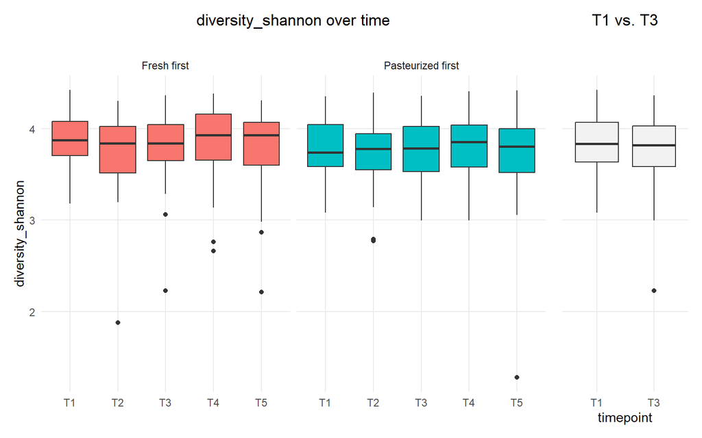

```r
plot_variable(dat, "diversity_shannon", cut_extremeValues = FALSE)
```

## Model comparison

Share of deviance explained (including p-values for testing the respective interaction model against the model without interaction):

```r
outputList_dvs <- compare_models("diversity_shannon")

outputList_dvs$tab_explainedDeviances %>% kable() %>% kable_styling()
```

| Model | Gaussian | Gaussian (log trafo) | Gamma |
| --- | --- | --- | --- |
| Raw intervention effect | 69.2% | 68% | 66.2% |
| Intervention effect by gender | 69.3% (p = 0.6838) | 68.2% (p = 0.5421) | 66.4% (p = 0.5629) |
| Intervention effect by age group | 69.3% (p = 0.6868) | 68.1% (p = 0.8067) | 66.2% (p = 0.8608) |
| Intervention effect by BMI group | 70.1% (p = 0.0204) | 68.9% (p = 0.0283) | 67.1% (p = 0.0234) |
| Intervention effect by fiber group | 69.2% (p = 0.9133) | 68.1% (p = 0.881) | 66.2% (p = 0.9335) |
| Intervention effect by baseline diversity | 67.5% (p = 0.0119) | 66.5% (p = 0.0119) | 64.2% (p = 0.0066) |

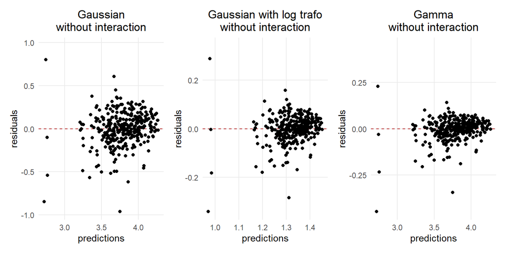

```r
outputList_dvs$gg_residuals
```

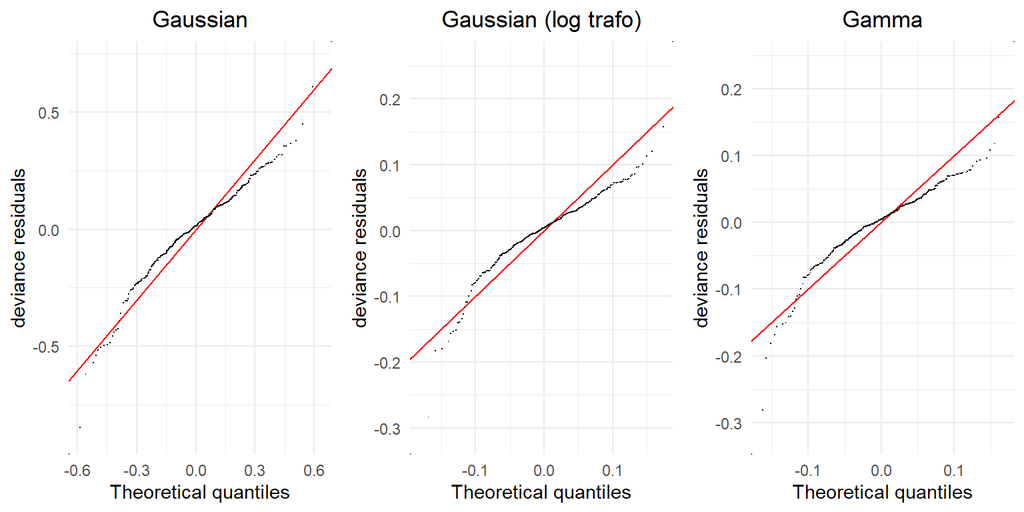

```r
mgcViz::gridPrint(outputList_dvs$qq_gaussian, outputList_dvs$qq_gaussianLog, outputList_dvs$qq_gamma, nrow = 1)
```

## Final model (Gaussian)

##### Estimated effects

```r
m_dvs <- outputList_dvs$model_gaussian

APCtools::create_modelSummary(list("Shannon diversity" = m_dvs), digits = 3)[[1]] %>% kable_styling()
```

| model | param | coef | se | CI_lower | CI_upper | pvalue |
| --- | --- | --- | --- | --- | --- | --- |
| Shannon diversity | (Intercept) | 3.782 | 0.053 | 3.679 | 3.885 | - |
| Shannon diversity | interventionFresh | -0.020 | 0.029 | -0.077 | 0.038 | 0.4988 |
| Shannon diversity | interventionPasteurized | -0.007 | 0.029 | -0.064 | 0.051 | 0.8255 |
| Shannon diversity | phasephase 2 | 0.024 | 0.024 | -0.023 | 0.072 | 0.3178 |
| Shannon diversity | genderW | 0.060 | 0.068 | -0.072 | 0.192 | 0.376 |
| Shannon diversity | age_centered50 | 0.002 | 0.002 | -0.002 | 0.007 | 0.3127 |
| Shannon diversity | bmi_centered25 | 0.014 | 0.012 | -0.009 | 0.036 | 0.2368 |

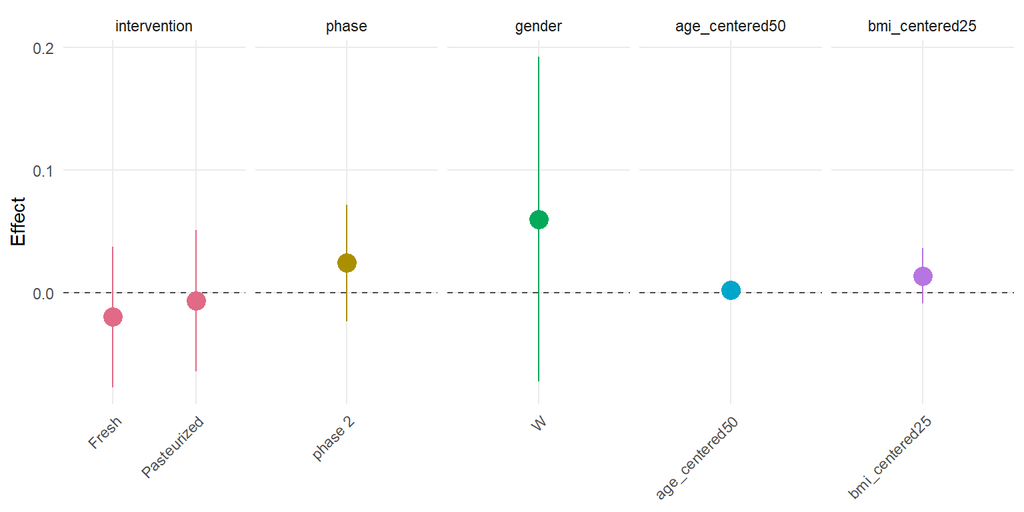

```r
APCtools::plot_linearEffects(m_dvs)
```

```r
# save the interaction models for later use for visualization
m_dvs_sexInt            <- outputList_dvs$model_gaussian_sexInt
m_dvs_sexInt_changedRef <- outputList_dvs$model_gaussian_sexInt_changedRef
m_dvs_ageInt            <- outputList_dvs$model_gaussian_ageInt
m_dvs_ageInt_changedRef <- outputList_dvs$model_gaussian_ageInt_changedRef
m_dvs_bmiInt            <- outputList_dvs$model_gaussian_bmiInt
m_dvs_bmiInt_changedRef <- outputList_dvs$model_gaussian_bmiInt_changedRef
m_dvs_fibInt            <- outputList_dvs$model_gaussian_fibInt
m_dvs_fibInt_changedRef <- outputList_dvs$model_gaussian_fibInt_changedRef
m_dvs_divInt            <- outputList_dvs$model_gaussian_divInt
m_dvs_divInt_changedRef <- outputList_dvs$model_gaussian_divInt_changedRef
```

# inverse Simpson diversity

## Description

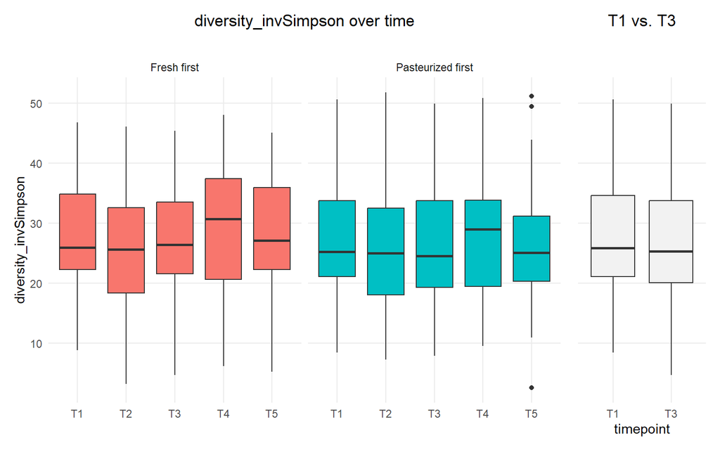

```r
plot_variable(dat, "diversity_invSimpson", cut_extremeValues = FALSE)
```

## Model comparison

Share of deviance explained (including p-values for testing the respective interaction model against the model without interaction):

```r
outputList_dvi <- compare_models("diversity_invSimpson")

outputList_dvi$tab_explainedDeviances %>% kable() %>% kable_styling()
```

| Model | Gaussian | Gaussian (log trafo) | Gamma |
| --- | --- | --- | --- |
| Raw intervention effect | 57.1% | 56.4% | 52.2% |
| Intervention effect by gender | 57.1% (p = 0.9762) | 56.4% (p = 0.8486) | 52.2% (p = 0.8109) |
| Intervention effect by age group | 57.4% (p = 0.3967) | 56.6% (p = 0.4485) | 52.3% (p = 0.6716) |
| Intervention effect by BMI group | 58.2% (p = 0.0306) | 57.7% (p = 0.0154) | 53.6% (p = 0.008) |
| Intervention effect by fiber group | 57.4% (p = 0.4696) | 56.4% (p = 0.8751) | 52.2% (p = 0.8929) |
| Intervention effect by baseline diversity | 52.6% (p = 0.0686) | 53.1% (p = 0.0445) | 46.3% (p = 0.0074) |

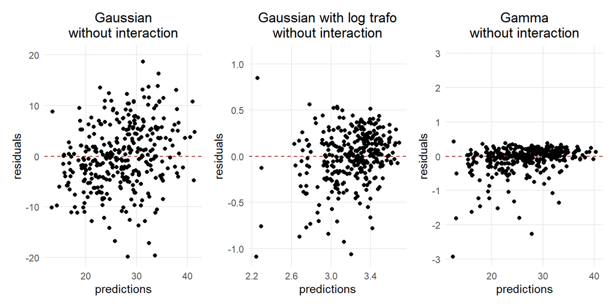

```r
outputList_dvi$gg_residuals
```

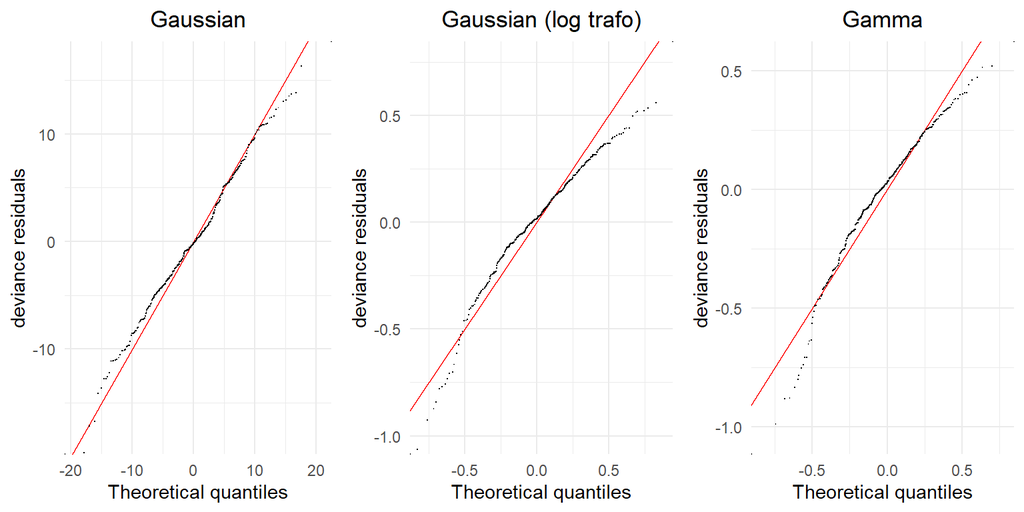

```r
mgcViz::gridPrint(outputList_dvi$qq_gaussian, outputList_dvi$qq_gaussianLog, outputList_dvi$qq_gamma, nrow = 1)
```

## Final model (Gaussian)

##### Estimated effects

```r
m_dvi <- outputList_dvi$model_gaussian

APCtools::create_modelSummary(list("inverse Simpson diversity" = m_dvi), digits = 3)[[1]] %>% kable_styling()
```

| model | param | coef | se | CI_lower | CI_upper | pvalue |
| --- | --- | --- | --- | --- | --- | --- |
| inverse Simpson diversity | (Intercept) | 27.365 | 1.372 | 24.676 | 30.054 | - |
| inverse Simpson diversity | interventionFresh | -0.161 | 0.936 | -1.996 | 1.674 | 0.8637 |
| inverse Simpson diversity | interventionPasteurized | 0.441 | 0.940 | -1.401 | 2.284 | 0.639 |
| inverse Simpson diversity | phasephase 2 | 0.864 | 0.770 | -0.645 | 2.374 | 0.2627 |
| inverse Simpson diversity | genderW | -0.487 | 1.714 | -3.845 | 2.872 | 0.7766 |
| inverse Simpson diversity | age_centered50 | 0.084 | 0.059 | -0.032 | 0.200 | 0.1559 |
| inverse Simpson diversity | bmi_centered25 | 0.176 | 0.294 | -0.400 | 0.752 | 0.5493 |

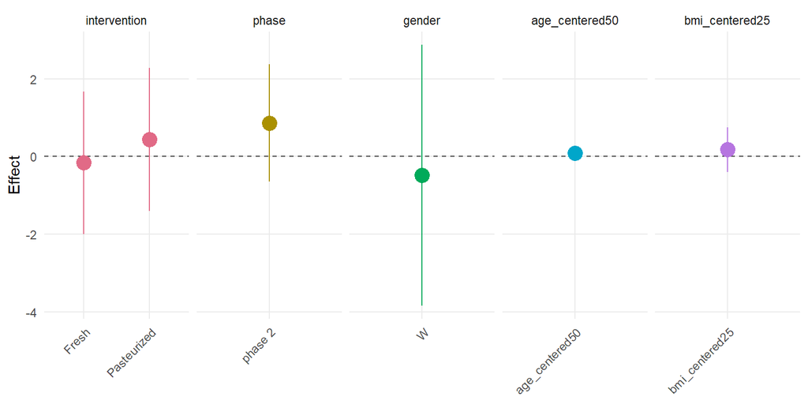

```r
APCtools::plot_linearEffects(m_dvi)
```

```r
# save the interaction models for later use for visualization
m_dvi_sexInt            <- outputList_dvi$model_gaussian_sexInt
m_dvi_sexInt_changedRef <- outputList_dvi$model_gaussian_sexInt_changedRef
m_dvi_ageInt            <- outputList_dvi$model_gaussian_ageInt
m_dvi_ageInt_changedRef <- outputList_dvi$model_gaussian_ageInt_changedRef
m_dvi_bmiInt            <- outputList_dvi$model_gaussian_bmiInt
m_dvi_bmiInt_changedRef <- outputList_dvi$model_gaussian_bmiInt_changedRef
m_dvi_fibInt            <- outputList_dvi$model_gaussian_fibInt
m_dvi_fibInt_changedRef <- outputList_dvi$model_gaussian_fibInt_changedRef
m_dvi_divInt            <- outputList_dvi$model_gaussian_divInt
m_dvi_divInt_changedRef <- outputList_dvi$model_gaussian_divInt_changedRef
```

# Observed Richness

## Description

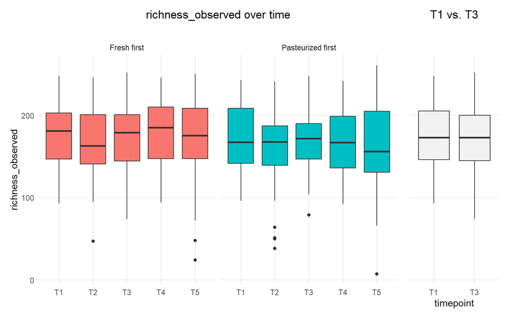

```r
plot_variable(dat, "richness_observed", cut_extremeValues = FALSE)
```

## Model comparison

Share of deviance explained (including p-values for testing the respective interaction model against the model without interaction):

```r
outputList_rno <- compare_models("richness_observed")

outputList_rno$tab_explainedDeviances %>% kable() %>% kable_styling()
```

| Model | Gaussian | Gaussian (log trafo) | Gamma |
| --- | --- | --- | --- |
| Raw intervention effect | 77.7% | 69.9% | 69.9% |
| Intervention effect by gender | 77.8% (p = 0.7352) | 69.9% (p = 0.9122) | 69.9% (p = 0.8871) |
| Intervention effect by age group | 77.8% (p = 0.7183) | 69.9% (p = 0.9759) | 69.9% (p = 0.8998) |
| Intervention effect by BMI group | 77.8% (p = 0.7969) | 69.9% (p = 0.8) | 69.8% (p = 0.9999) |
| Intervention effect by fiber group | 77.8% (p = 0.7066) | 69.9% (p = 0.9489) | 69.9% (p = 0.9014) |
| Intervention effect by baseline diversity | 77.3% (p = 2e-04) | 69.1% (p = 0.0161) | 68.9% (p = 0.0022) |

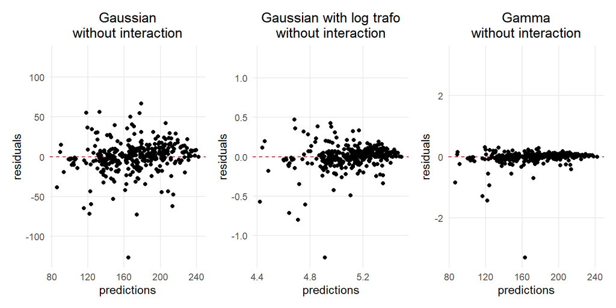

```r
outputList_rno$gg_residuals
```

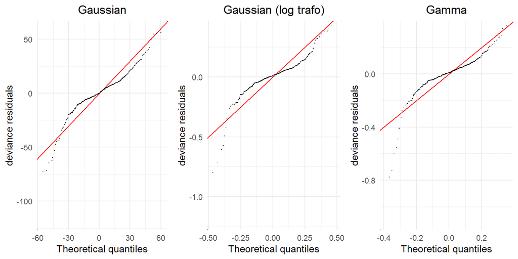

```r
mgcViz::gridPrint(outputList_rno$qq_gaussian, outputList_rno$qq_gaussianLog, outputList_rno$qq_gamma, nrow = 1)
```

## Final model (Gaussian)

##### Estimated effects

```r
m_rno <- outputList_rno$model_gaussian

APCtools::create_modelSummary(list("Observed richness" = m_rno), digits = 3)[[1]] %>% kable_styling()
```

| model | param | coef | se | CI_lower | CI_upper | pvalue |
| --- | --- | --- | --- | --- | --- | --- |
| Observed richness | (Intercept) | 166.789 | 6.123 | 154.789 | 178.790 | - |
| Observed richness | interventionFresh | -4.586 | 2.937 | -10.342 | 1.171 | 0.1197 |
| Observed richness | interventionPasteurized | -4.043 | 2.949 | -9.822 | 1.736 | 0.1715 |
| Observed richness | phasephase 2 | 2.923 | 2.419 | -1.819 | 7.665 | 0.2281 |
| Observed richness | genderW | 16.505 | 7.986 | 0.853 | 32.157 | 0.0397 |
| Observed richness | age_centered50 | 0.587 | 0.275 | 0.048 | 1.126 | 0.0336 |
| Observed richness | bmi_centered25 | 1.318 | 1.368 | -1.364 | 4.001 | 0.3363 |

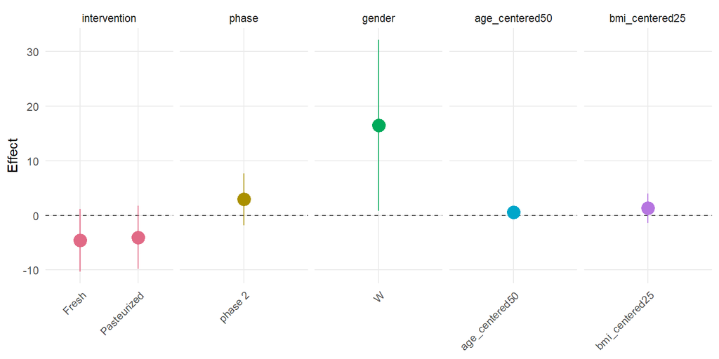

```r
APCtools::plot_linearEffects(m_rno)
```

```r
# save the interaction models for later use for visualization
m_rno_sexInt            <- outputList_rno$model_gaussian_sexInt
m_rno_sexInt_changedRef <- outputList_rno$model_gaussian_sexInt_changedRef
m_rno_ageInt            <- outputList_rno$model_gaussian_ageInt
m_rno_ageInt_changedRef <- outputList_rno$model_gaussian_ageInt_changedRef
m_rno_bmiInt            <- outputList_rno$model_gaussian_bmiInt
m_rno_bmiInt_changedRef <- outputList_rno$model_gaussian_bmiInt_changedRef
m_rno_fibInt            <- outputList_rno$model_gaussian_fibInt
m_rno_fibInt_changedRef <- outputList_rno$model_gaussian_fibInt_changedRef
m_rno_divInt            <- outputList_rno$model_gaussian_divInt
m_rno_divInt_changedRef <- outputList_rno$model_gaussian_divInt_changedRef
```

# Richness Hill

## Description

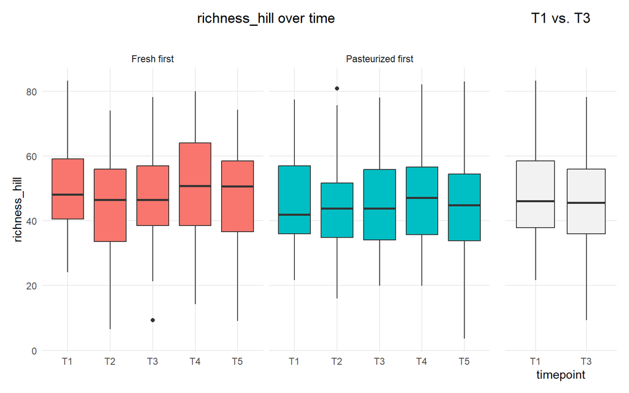

```r
plot_variable(dat, "richness_hill", cut_extremeValues = FALSE)
```

## Model comparison

Share of deviance explained (including p-values for testing the respective interaction model against the model without interaction):

```r
outputList_rnh <- compare_models("richness_hill")

outputList_rnh$tab_explainedDeviances %>% kable() %>% kable_styling()
```

| Model | Gaussian | Gaussian (log trafo) | Gamma |
| --- | --- | --- | --- |
| Raw intervention effect | 71.1% | 69.2% | 66.5% |
| Intervention effect by gender | 71.1% (p = 0.9367) | 69.3% (p = 0.6838) | 66.5% (p = 0.7352) |
| Intervention effect by age group | 71.3% (p = 0.4425) | 69.3% (p = 0.6868) | 66.5% (p = 0.8799) |
| Intervention effect by BMI group | 71.8% (p = 0.0304) | 70.1% (p = 0.0204) | 67.5% (p = 0.0117) |
| Intervention effect by fiber group | 71.3% (p = 0.4944) | 69.2% (p = 0.9133) | 66.5% (p = 0.9446) |
| Intervention effect by baseline diversity | 69.1% (p = 0.014) | 67.5% (p = 0.0119) | 63.6% (p = 0.0022) |

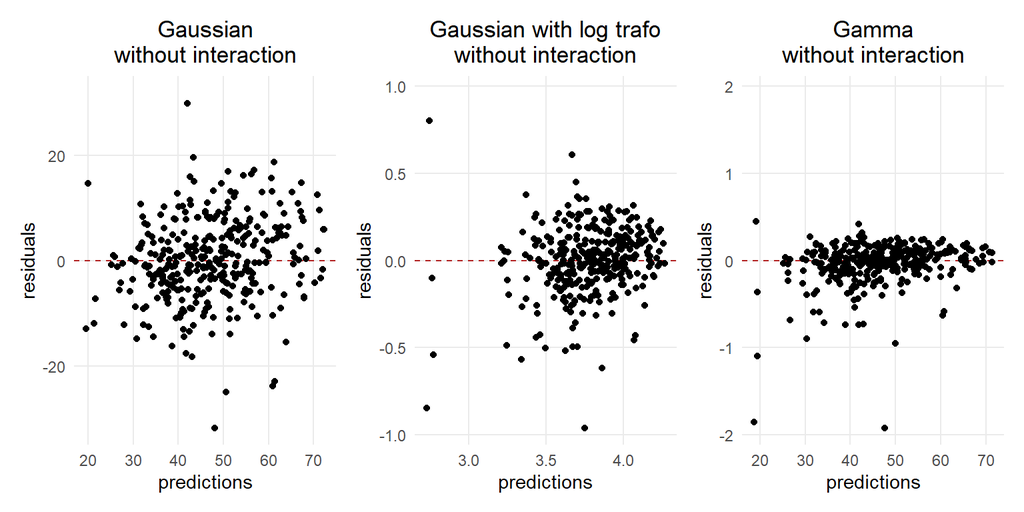

```r
outputList_rnh$gg_residuals
```

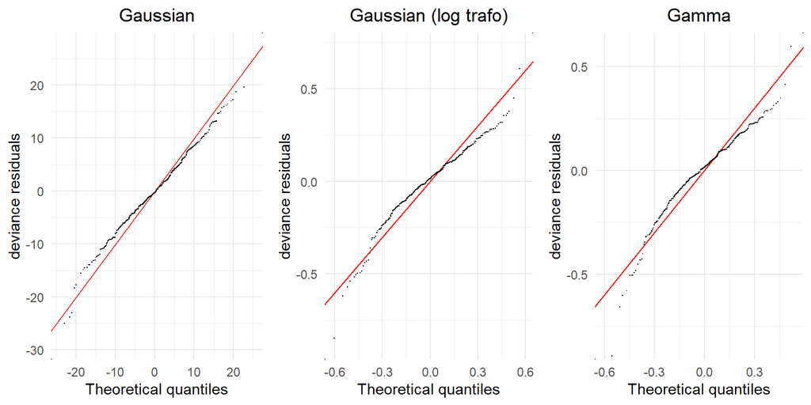

```r
mgcViz::gridPrint(outputList_rnh$qq_gaussian, outputList_rnh$qq_gaussianLog, outputList_rnh$qq_gamma, nrow = 1)
```

## Final model (Gaussian)

##### Estimated effects

```r
m_rnh <- outputList_rnh$model_gaussian

APCtools::create_modelSummary(list("Richness Hill" = m_rnh), digits = 3)[[1]] %>% kable_styling()
```

| model | param | coef | se | CI_lower | CI_upper | pvalue |
| --- | --- | --- | --- | --- | --- | --- |
| Richness Hill | (Intercept) | 46.951 | 2.182 | 42.675 | 51.227 | - |
| Richness Hill | interventionFresh | -0.508 | 1.184 | -2.829 | 1.812 | 0.668 |
| Richness Hill | interventionPasteurized | 0.326 | 1.189 | -2.004 | 2.656 | 0.7841 |
| Richness Hill | phasephase 2 | 1.208 | 0.975 | -0.703 | 3.119 | 0.2164 |
| Richness Hill | genderW | 1.503 | 2.813 | -4.011 | 7.017 | 0.5936 |
| Richness Hill | age_centered50 | 0.176 | 0.097 | -0.014 | 0.366 | 0.0702 |
| Richness Hill | bmi_centered25 | 0.402 | 0.482 | -0.543 | 1.347 | 0.4048 |

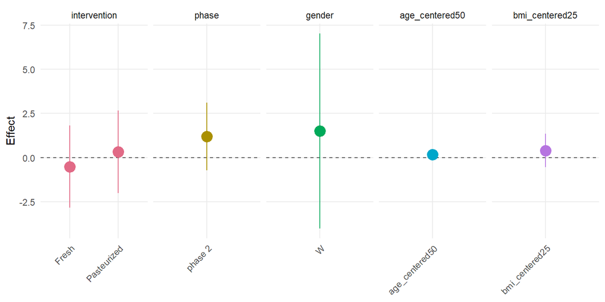

```r
APCtools::plot_linearEffects(m_rnh)
```

```r
# save the interaction models for later use for visualization
m_rnh_sexInt            <- outputList_rnh$model_gaussian_sexInt
m_rnh_sexInt_changedRef <- outputList_rnh$model_gaussian_sexInt_changedRef
m_rnh_ageInt            <- outputList_rnh$model_gaussian_ageInt
m_rnh_ageInt_changedRef <- outputList_rnh$model_gaussian_ageInt_changedRef
m_rnh_bmiInt            <- outputList_rnh$model_gaussian_bmiInt
m_rnh_bmiInt_changedRef <- outputList_rnh$model_gaussian_bmiInt_changedRef
m_rnh_fibInt            <- outputList_rnh$model_gaussian_fibInt
m_rnh_fibInt_changedRef <- outputList_rnh$model_gaussian_fibInt_changedRef
m_rnh_divInt            <- outputList_rnh$model_gaussian_divInt
m_rnh_divInt_changedRef <- outputList_rnh$model_gaussian_divInt_changedRef
```

# Evenness Pielou

## Description

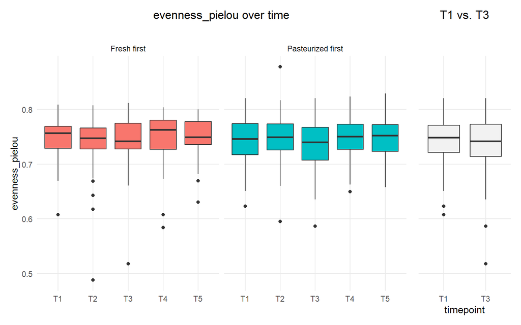

```r
plot_variable(dat, "evenness_pielou", cut_extremeValues = FALSE)
```

## Model comparison

Share of deviance explained (including p-values for testing the respective interaction model against the model without interaction):

```r
outputList_enp <- compare_models("evenness_pielou")

outputList_enp$tab_explainedDeviances %>% kable() %>% kable_styling()
```

| Model | Gaussian | Gaussian (log trafo) | Gamma |
| --- | --- | --- | --- |
| Raw intervention effect | 55.7% | 55.6% | 53.4% |
| Intervention effect by gender | 55.9% (p = 0.4623) | 55.9% (p = 0.4248) | 53.7% (p = 0.4129) |
| Intervention effect by age group | 55.9% (p = 0.4109) | 55.8% (p = 0.445) | 53.6% (p = 0.4768) |
| Intervention effect by BMI group | 57.1% (p = 0.0145) | 57% (p = 0.0162) | 54.8% (p = 0.0149) |
| Intervention effect by fiber group | 55.7% (p = 0.9452) | 55.6% (p = 0.956) | 53.4% (p = 0.9672) |
| Intervention effect by baseline diversity | 53.5% (p = 0.0312) | 53.6% (p = 0.0298) | 51% (p = 0.0277) |

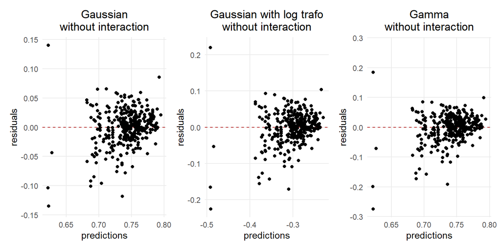

```r
outputList_enp$gg_residuals
```

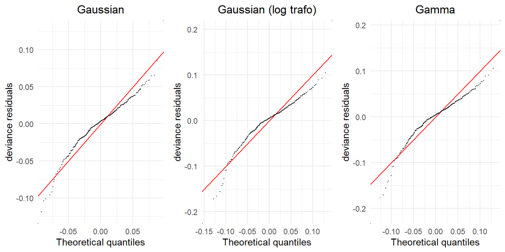

```r
mgcViz::gridPrint(outputList_enp$qq_gaussian, outputList_enp$qq_gaussianLog, outputList_enp$qq_gamma, nrow = 1)
```

## Final model (Gaussian)

##### Estimated effects

```r
m_enp <- outputList_enp$model_gaussian

APCtools::create_modelSummary(list("Evenness Pielou" = m_enp), digits = 3)[[1]] %>% kable_styling()
```

| model | param | coef | se | CI_lower | CI_upper | pvalue |
| --- | --- | --- | --- | --- | --- | --- |
| Evenness Pielou | (Intercept) | 0.745 | 0.007 | 0.732 | 0.758 | - |
| Evenness Pielou | interventionFresh | 0.001 | 0.005 | -0.008 | 0.010 | 0.9048 |
| Evenness Pielou | interventionPasteurized | 0.006 | 0.005 | -0.003 | 0.015 | 0.2198 |
| Evenness Pielou | phasephase 2 | 0.000 | 0.004 | -0.008 | 0.007 | 0.9753 |
| Evenness Pielou | genderW | -0.005 | 0.008 | -0.021 | 0.012 | 0.5745 |
| Evenness Pielou | age_centered50 | 0.000 | 0.000 | -0.001 | 0.001 | 0.8888 |
| Evenness Pielou | bmi_centered25 | 0.001 | 0.001 | -0.001 | 0.004 | 0.3064 |

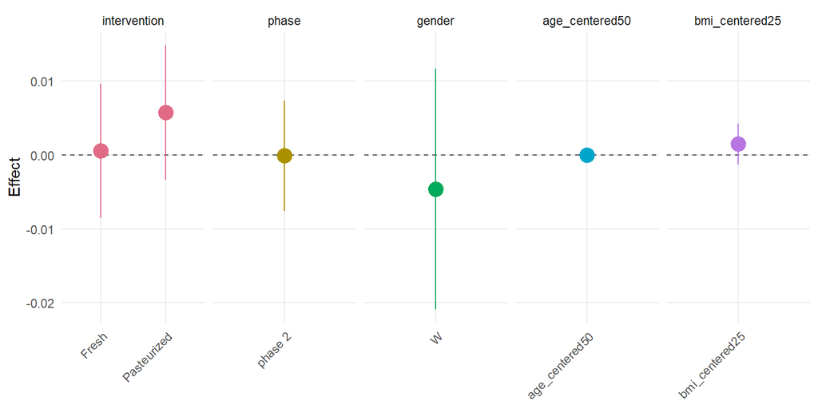

```r
APCtools::plot_linearEffects(m_enp)
```

```r
# save the interaction models for later use for visualization
m_enp_sexInt            <- outputList_enp$model_gaussian_sexInt
m_enp_sexInt_changedRef <- outputList_enp$model_gaussian_sexInt_changedRef
m_enp_ageInt            <- outputList_enp$model_gaussian_ageInt
m_enp_ageInt_changedRef <- outputList_enp$model_gaussian_ageInt_changedRef
m_enp_bmiInt            <- outputList_enp$model_gaussian_bmiInt
m_enp_bmiInt_changedRef <- outputList_enp$model_gaussian_bmiInt_changedRef
m_enp_fibInt            <- outputList_enp$model_gaussian_fibInt
m_enp_fibInt_changedRef <- outputList_enp$model_gaussian_fibInt_changedRef
m_enp_divInt            <- outputList_enp$model_gaussian_divInt
m_enp_divInt_changedRef <- outputList_enp$model_gaussian_divInt_changedRef
```

# Evenness Simpson

## Description

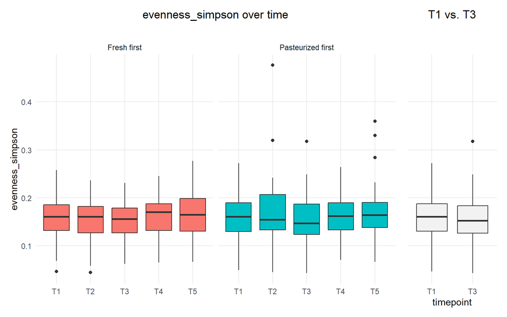

```r
plot_variable(dat, "evenness_simpson", cut_extremeValues = FALSE)
```

## Model comparison

Share of deviance explained (including p-values for testing the respective interaction model against the model without interaction):

```r
outputList_ens <- compare_models("evenness_simpson")

outputList_ens$tab_explainedDeviances %>% kable() %>% kable_styling()
```

| Model | Gaussian | Gaussian (log trafo) | Gamma |
| --- | --- | --- | --- |
| Raw intervention effect | 43.4% | 45.6% | 41.8% |
| Intervention effect by gender | 43.5% (p = 0.7372) | 45.6% (p = 0.8145) | 41.9% (p = 0.7379) |
| Intervention effect by age group | 43.8% (p = 0.3638) | 46.1% (p = 0.2844) | 42.1% (p = 0.435) |
| Intervention effect by BMI group | 44.6% (p = 0.0608) | 47.1% (p = 0.0222) | 43.3% (p = 0.0243) |
| Intervention effect by fiber group | 43.4% (p = 0.8855) | 45.5% (p = 0.9999) | 41.7% (p = 0.9999) |
| Intervention effect by baseline diversity | 42.5% (p = 0.043) | 44.8% (p = 0.041) | 40.9% (p = 0.0421) |

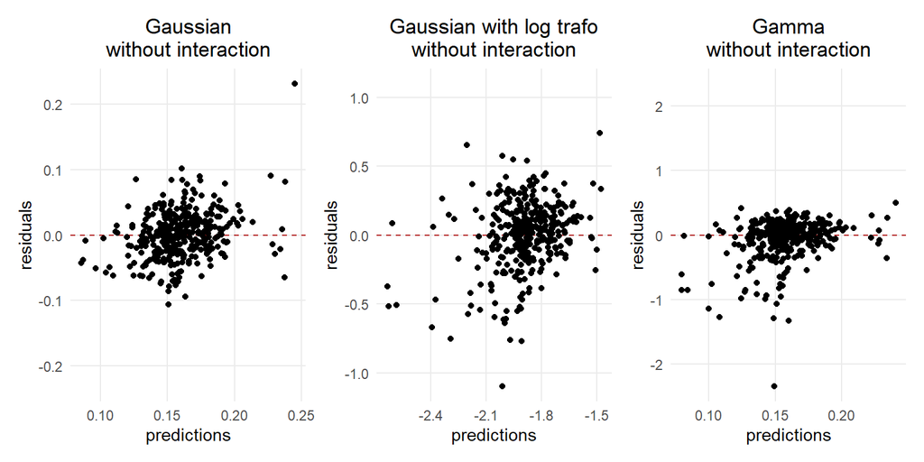

```r
outputList_ens$gg_residuals
```

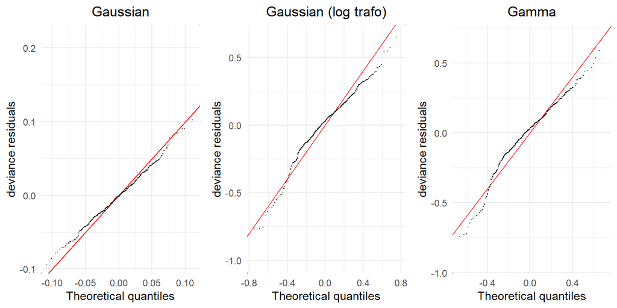

```r
mgcViz::gridPrint(outputList_ens$qq_gaussian, outputList_ens$qq_gaussianLog, outputList_ens$qq_gamma, nrow = 1)
```

## Final model (log Gaussian)

##### Estimated effects

```r
m_ens <- outputList_ens$model_gaussianLog

APCtools::create_modelSummary(list("Evenness Simpson" = m_ens), digits = 3)[[1]] %>% kable_styling()
```

| model | param | coef | se | CI_lower | CI_upper | pvalue |
| --- | --- | --- | --- | --- | --- | --- |
| Evenness Simpson | (Intercept) | -1.848 | 0.046 | -1.938 | -1.759 | - |
| Evenness Simpson | interventionFresh | 0.021 | 0.037 | -0.050 | 0.093 | 0.5594 |
| Evenness Simpson | interventionPasteurized | 0.051 | 0.037 | -0.021 | 0.123 | 0.1679 |
| Evenness Simpson | phasephase 2 | 0.008 | 0.030 | -0.051 | 0.067 | 0.8008 |
| Evenness Simpson | genderW | -0.127 | 0.055 | -0.235 | -0.020 | 0.0209 |
| Evenness Simpson | age_centered50 | -0.001 | 0.002 | -0.005 | 0.002 | 0.429 |
| Evenness Simpson | bmi_centered25 | -0.001 | 0.009 | -0.019 | 0.017 | 0.9122 |

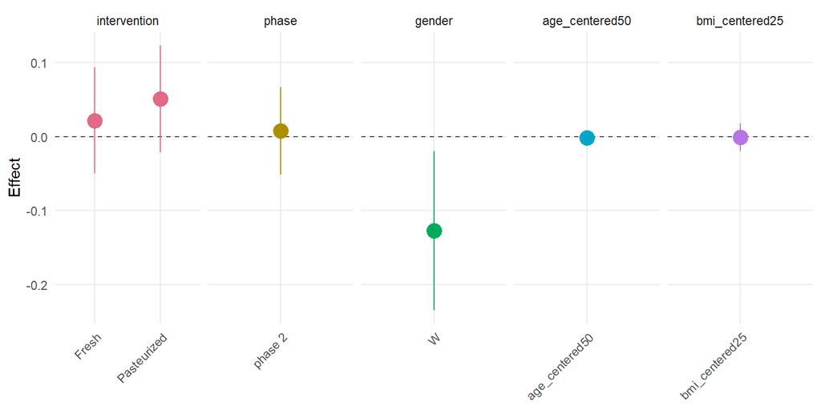

```r
APCtools::plot_linearEffects(m_ens)
```

```r
# save the interaction models for later use for visualization
m_ens_sexInt            <- outputList_ens$model_gaussianLog_sexInt
m_ens_sexInt_changedRef <- outputList_ens$model_gaussianLog_sexInt_changedRef
m_ens_ageInt            <- outputList_ens$model_gaussianLog_ageInt
m_ens_ageInt_changedRef <- outputList_ens$model_gaussianLog_ageInt_changedRef
m_ens_bmiInt            <- outputList_ens$model_gaussianLog_bmiInt
m_ens_bmiInt_changedRef <- outputList_ens$model_gaussianLog_bmiInt_changedRef
m_ens_fibInt            <- outputList_ens$model_gaussianLog_fibInt
m_ens_fibInt_changedRef <- outputList_ens$model_gaussianLog_fibInt_changedRef
m_ens_divInt            <- outputList_ens$model_gaussianLog_divInt
m_ens_divInt_changedRef <- outputList_ens$model_gaussianLog_divInt_changedRef
```

# Dominance dbp

## Description

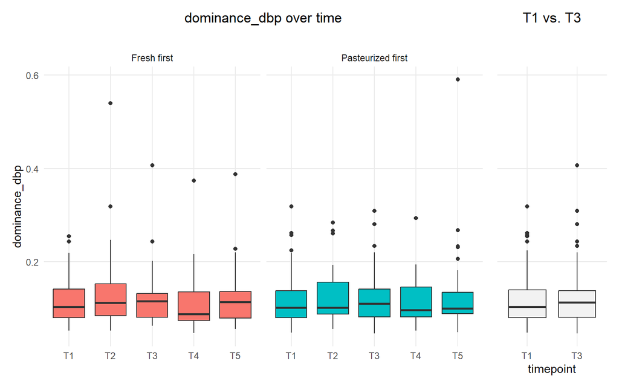

```r
plot_variable(dat, "dominance_dbp", cut_extremeValues = FALSE)
```

## Model comparison

Share of deviance explained (including p-values for testing the respective interaction model against the model without interaction):

```r
outputList_dbp <- compare_models("dominance_dbp")

outputList_dbp$tab_explainedDeviances %>% kable() %>% kable_styling()
```

| Model | Gaussian | Gaussian (log trafo) | Gamma |
| --- | --- | --- | --- |
| Raw intervention effect | 43.2% | 44.2% | 49.1% |
| Intervention effect by gender | 43.3% (p = 0.8333) | 44.3% (p = 0.7976) | 49.2% (p = 0.8699) |
| Intervention effect by age group | 43.5% (p = 0.4647) | 44.5% (p = 0.423) | 49.6% (p = 0.3221) |
| Intervention effect by BMI group | 44.5% (p = 0.0384) | 45.6% (p = 0.0208) | 50.4% (p = 0.0349) |
| Intervention effect by fiber group | 43.3% (p = 0.8372) | 44.4% (p = 0.6788) | 49.3% (p = 0.7511) |
| Intervention effect by baseline diversity | 40.8% (p = 0.1444) | 40.7% (p = 0.2129) | 47% (p = 0.1856) |

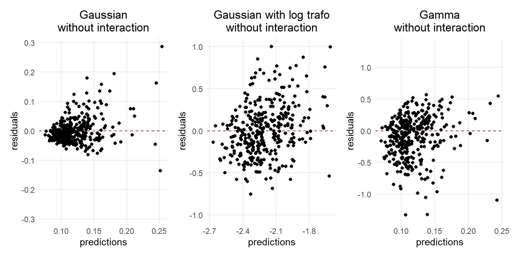

```r
outputList_dbp$gg_residuals
```

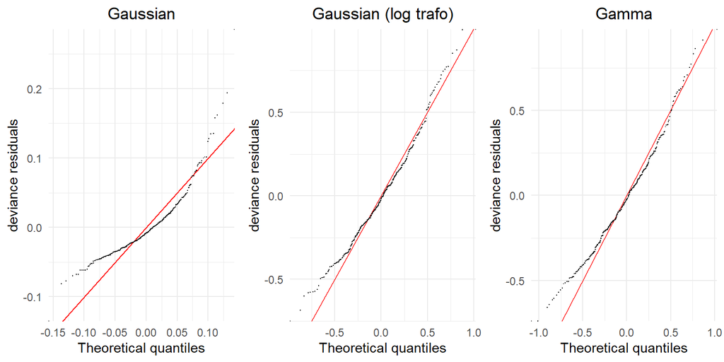

```r
mgcViz::gridPrint(outputList_dbp$qq_gaussian, outputList_dbp$qq_gaussianLog, outputList_dbp$qq_gamma, nrow = 1)
```

## Final model (Gamma)

##### Estimated effects

```r
m_dbp <- outputList_dbp$model_gamma

APCtools::create_modelSummary(list("Dominance dbp" = m_dbp), digits = 3)[[1]] %>% kable_styling()
```

| model | param | coef | se | CI_lower | CI_upper | coef_exp | se_exp | CI_lower_exp | CI_upper_exp | pvalue |
| --- | --- | --- | --- | --- | --- | --- | --- | --- | --- | --- |
| Dominance dbp | (Intercept) | -2.185 | 0.062 | -2.307 | -2.064 | 0.112 | 1.064 | 0.100 | 0.127 | - |
| Dominance dbp | interventionFresh | 0.007 | 0.047 | -0.086 | 0.100 | 1.007 | 1.049 | 0.918 | 1.105 | 0.8843 |
| Dominance dbp | interventionPasteurized | -0.018 | 0.048 | -0.111 | 0.075 | 0.982 | 1.049 | 0.895 | 1.078 | 0.7035 |
| Dominance dbp | phasephase 2 | -0.044 | 0.039 | -0.120 | 0.033 | 0.957 | 1.040 | 0.887 | 1.033 | 0.2648 |
| Dominance dbp | genderW | 0.063 | 0.076 | -0.086 | 0.211 | 1.065 | 1.079 | 0.918 | 1.235 | 0.4083 |
| Dominance dbp | age_centered50 | -0.001 | 0.003 | -0.006 | 0.004 | 0.999 | 1.003 | 0.994 | 1.004 | 0.638 |
| Dominance dbp | bmi_centered25 | -0.004 | 0.013 | -0.029 | 0.021 | 0.996 | 1.013 | 0.971 | 1.022 | 0.7589 |

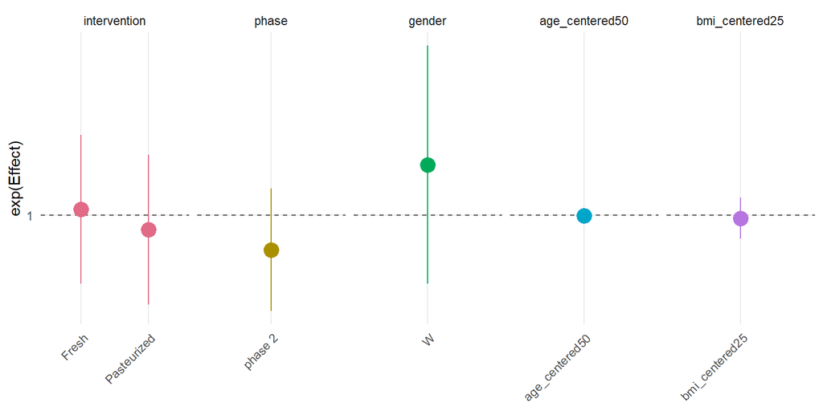

```r
APCtools::plot_linearEffects(m_dbp)
```

```r
# save the interaction models for later use for visualization
m_dbp_sexInt            <- outputList_dbp$model_gamma_sexInt
m_dbp_sexInt_changedRef <- outputList_dbp$model_gamma_sexInt_changedRef
m_dbp_ageInt            <- outputList_dbp$model_gamma_ageInt
m_dbp_ageInt_changedRef <- outputList_dbp$model_gamma_ageInt_changedRef
m_dbp_bmiInt            <- outputList_dbp$model_gamma_bmiInt
m_dbp_bmiInt_changedRef <- outputList_dbp$model_gamma_bmiInt_changedRef
m_dbp_fibInt            <- outputList_dbp$model_gamma_fibInt
m_dbp_fibInt_changedRef <- outputList_dbp$model_gamma_fibInt_changedRef
m_dbp_divInt            <- outputList_dbp$model_gamma_divInt
m_dbp_divInt_changedRef <- outputList_dbp$model_gamma_divInt_changedRef
```

# Dominance core abundance

## Description

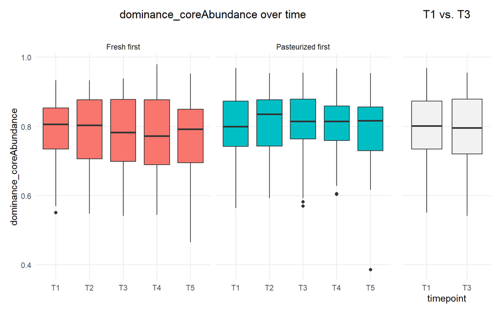

```r
plot_variable(dat, "dominance_coreAbundance", cut_extremeValues = FALSE)
```

## Model comparison

Share of deviance explained (including p-values for testing the respective interaction model against the model without interaction):

```r
outputList_dca <- compare_models("dominance_coreAbundance")

outputList_dca$tab_explainedDeviances %>% kable() %>% kable_styling()
```

| Model | Gaussian | Gaussian (log trafo) | Gamma |
| --- | --- | --- | --- |
| Raw intervention effect | 83.1% | 82.5% | 81.9% |
| Intervention effect by gender | 83.2% (p = 0.5814) | 82.6% (p = 0.5677) | 82% (p = 0.5934) |
| Intervention effect by age group | 83.3% (p = 0.4275) | 82.6% (p = 0.3853) | 82% (p = 0.4092) |
| Intervention effect by BMI group | 83.3% (p = 0.3207) | 82.6% (p = 0.3474) | 82% (p = 0.3236) |
| Intervention effect by fiber group | 83.2% (p = 0.6691) | 82.5% (p = 0.7053) | 81.9% (p = 0.6896) |
| Intervention effect by baseline diversity | 83.1% (p = 0.9999) | 82.4% (p = 0.9999) | 81.8% (p = 0.9999) |

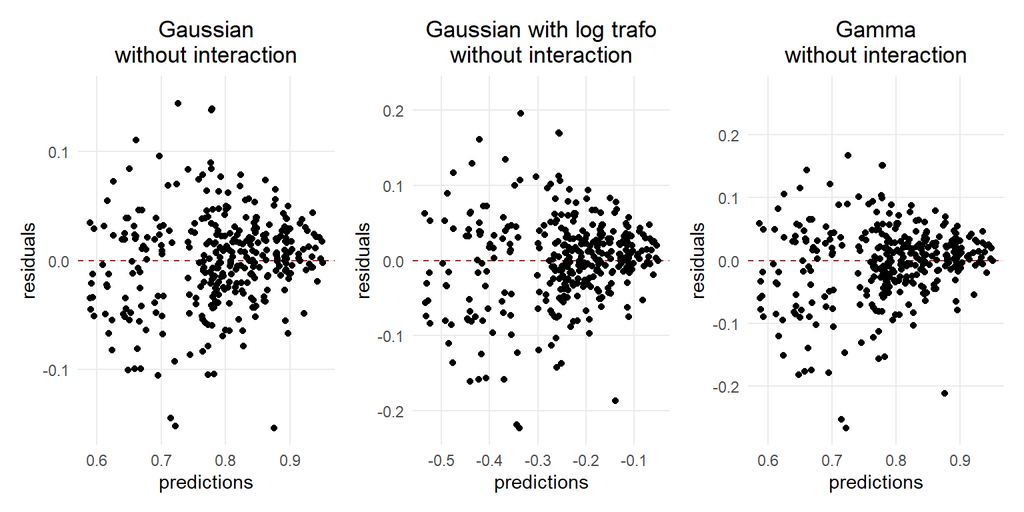

```r
outputList_dca$gg_residuals
```

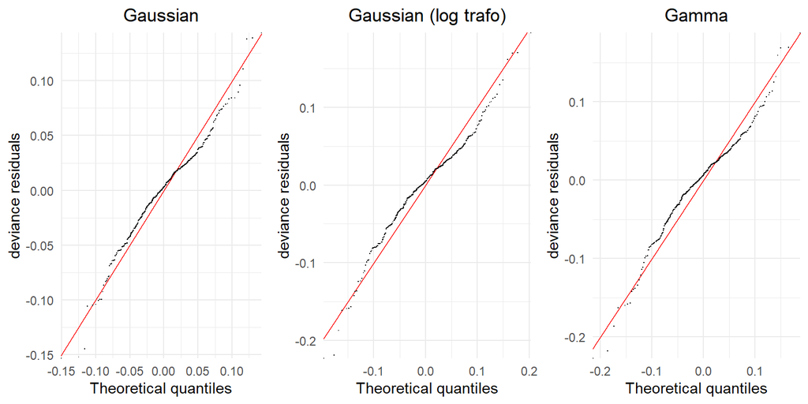

```r
mgcViz::gridPrint(outputList_dca$qq_gaussian, outputList_dca$qq_gaussianLog, outputList_dca$qq_gamma, nrow = 1)
```